# 04C_CellTypeSignatures

```r
suppressMessages({
    suppressWarnings({
        library(OmnipathR)
        library(Seurat)
        library("org.Mm.eg.db", quietly = T)
        library(biomaRt, quietly = T)
        library(ggplot2)
        library(dplyr)
        library(reshape2)
        library(dplyr)
        library(broom)
    })
})

source('./utility_functions.r')
```

```
Allowing parallel execution with up to 30 working processes.
```

```r
server = 'mando'
if (server == 'jabba'){
    data_path = '/data3/hratch/norcross_abc/'
}else if (server == 'mando'){
    data_path = '/data/hratch/norcross_abc/'
}
```

correlates of cell proportion: https://www.sciencedirect.com/science/article/pii/S0092867419307329 cell type specific correlation of pathway

may want to use metacells again

```r
abc.integrated<-readRDS(paste0(data_path, 'processed/abc_annotated.RDS'))
md<-abc.integrated@meta.data
# human.genes<-sapply(VariableFeatures(abc.integrated), function(x) toupper(x))
#                     human.genes<-unlist(unname(human.genes))
```

```r
inflammasome.go.terms<-c("GO:0061702", 'GO:1904784', 'GO:0140973', 'GO:0140970', 'GO:0140738', 'GO:0140632',
                         'GO:0140633', 'GO:0140634', 'GO:1900227', 'GO:0044546', 'GO:0097169', 'GO:0160074',
                         'GO:0160075', 'GO:0072559', 'GO:0072557', 'GO:0072558')
type1.ifns.go.terms<-c('GO:1990231', 'GO:0032606', 'GO:0019962', 'GO:0038197', 'GO:0034340', 'GO:0005132',
                       'GO:0004905', 'GO:0032481', 'GO:0060337', 'GO:0071357', 'GO:0060340')
```

```r
inflammasome <- unique(AnnotationDbi::select(org.Mm.eg.db, inflammasome.go.terms, columns = c('SYMBOL'), keytype = "GOALL")$SYMBOL)
inflammasome
```

1. 'Casp1'

2. 'Casp4'

3. 'Casp12'

4. 'Ddx3x'

5. 'Naip1'

6. 'Naip2'

7. 'Naip5'

8. 'Naip6'

9. 'Naip7'

10. 'Mefv'

11. 'Pycard'

12. 'Gsdmd'

13. 'Nlrp6'

14. 'Nlrp1a'

15. 'Nlrp3'

16. 'Dhx33'

17. 'Nlrp9a'

18. 'Nlrp9b'

19. 'Nlrc4'

20. 'Nlrp9c'

21. 'Aim2'

22. 'Nlrp1b'

23. NA

24. 'Cd36'

25. 'Myd88'

26. 'Eif2ak2'

27. 'Trim30a'

28. 'Tlr4'

29. 'Tlr6'

30. 'Nek7'

31. 'Sirt2'

32. '1810058I24Rik'

33. 'Atat1'

34. 'Usp50'

35. 'Cptp'

36. 'Trem2'

37. 'Gbp5'

38. 'Plcg2'

39. 'Nlrc3'

```r
type1.ifns <- unique(AnnotationDbi::select(org.Mm.eg.db, type1.ifns.go.terms, columns = c('SYMBOL'), keytype = "GOALL")$SYMBOL)
type1.ifns
```

1. 'Sting1'

2. 'Ap3b1'

3. 'Ap3d1'

4. 'Atg5'

5. 'Cd14'

6. 'Chuk'

7. 'Crebbp'

8. 'Ddx3x'

9. 'Dhx9'

10. 'Flot1'

11. 'Flt3'

12. 'Gapdh'

13. 'Hmgb1'

14. 'Hspd1'

15. 'Hsp90aa1'

16. 'Irf8'

17. 'Ifnar1'

18. 'Irak1'

19. 'Irf1'

20. 'Acod1'

21. 'Irf9'

22. 'Mmp12'

23. 'Gbp4'

24. 'Myd88'

25. 'Nmbr'

26. 'Pola1'

27. 'Ppm1b'

28. 'Ptpn11'

29. 'Ptpn22'

30. 'Sirpa'

31. 'Ptprs'

32. 'Rel'

33. 'Relb'

34. 'Stat1'

35. 'Syk'

36. 'Tlr4'

37. 'Traf3'

38. 'Traip'

39. 'Trex1'

40. 'Ufd1'

41. 'Yy1'

42. 'Banf1'

43. 'Oas1g'

44. 'Tlr2'

45. 'G3bp1'

46. 'Irf5'

47. 'Tomm70a'

48. 'Irf7'

49. 'Irf3'

50. 'Pqbp1'

51. 'Tbk1'

52. 'Zbtb20'

53. 'Nmi'

54. 'Pycard'

55. 'Riok3'

56. 'Polr3d'

57. 'Polr3g'

58. 'Atg12'

59. 'Rnf125'

60. 'Zcchc3'

61. 'Nmb'

62. 'Trim15'

63. 'Cactin'

64. 'Polr3f'

65. 'Polr3b'

66. 'Ifih1'

67. 'Rnf135'

68. 'Dhx36'

69. 'Ppme1'

70. 'Traf3ip1'

71. 'Polr3c'

72. 'Garin5a'

73. 'Rab2b'

74. 'Zc3hav1'

75. 'Dhx58'

76. 'Tlr9'

77. 'Hmgb2'

78. 'Oas1d'

79. 'Ticam1'

80. 'Rnf216'

81. 'D1Pas1'

82. 'Oas1c'

83. 'Tirap'

84. 'Tlr3'

85. 'Tlr7'

86. 'Tlr8'

87. 'Havcr2'

88. 'Rnf26'

89. 'Trim38'

90. 'Cgas'

91. 'Dhx33'

92. 'Nploc4'

93. 'Polr3a'

94. 'Ilrun'

95. 'Mavs'

96. 'Rigi'

97. 'Oas1e'

98. 'Plcg2'

99. 'Setd2'

100. 'Peli3'

101. 'Gpatch3'

102. 'Oas1f'

103. 'Atg9a'

104. 'Oas3'

105. 'Oas2'

106. 'Oas1h'

107. 'Oas1a'

108. 'Nlrc3'

109. 'Nlrx1'

110. 'Trim56'

111. 'Lrrc55os'

112. 'Isg15'

113. 'Ifnar2'

114. NA

115. 'Cdc37'

116. 'Ch25h'

117. 'Fadd'

118. 'Ifna1'

119. 'Ifnb1'

120. 'Cnot7'

121. 'Ptpn2'

122. 'Smpd1'

123. 'Sp100'

124. 'Stat2'

125. 'Wnt5a'

126. 'Ifi27'

127. 'Ube2k'

128. 'Usp27x'

129. 'Samhd1'

130. 'Mettl3'

131. 'Adar'

132. 'Ikbke'

133. 'Usp29'

134. 'Zbp1'

135. 'Ifitm3'

136. 'Lsm14a'

137. 'Mul1'

138. 'Ifitm1'

139. 'Ifitm7'

140. 'Dcst1'

141. 'Ifitm2'

142. 'Trim6'

143. 'Shmt2'

144. 'Rnf185'

145. 'Trim41'

146. 'Ifitm6'

147. 'Ythdf2'

148. 'Ttll12'

149. 'Ythdf3'

150. 'Shfl'

151. 'Nlrc5'

152. 'Ifna11'

153. 'Ifna2'

154. 'Ifna4'

155. 'Ifna5'

156. 'Ifna6'

157. 'Ifna7'

158. 'Ifna9'

159. 'Ifnab'

160. 'Ifna13'

161. 'Ifna16'

162. 'Ifne'

163. 'Ifna15'

164. 'Ifna12'

165. 'Ifnz'

166. 'Ifnk'

167. 'Ifna14'

168. 'Gm13271'

169. 'Gm13283'

170. 'Gm13272'

171. 'Gm13276'

172. 'Gm13277'

173. 'Gm13275'

Additionally, "oxidative stress" genes and "mitochondrial dysfunction" genes were downloaded from GeneCards, by searching each of these terms respectively

```r
# # https://www.r-bloggers.com/2016/10/converting-mouse-to-human-gene-names-with-biomart-package/
# convertHumanGeneList <- function(x){

#     human = useMart("ensembl", dataset = "hsapiens_gene_ensembl")
#     mouse = useMart("ensembl", dataset = "mmusculus_gene_ensembl")
#     genesV2 = biomaRt::getLDS(attributes = c("hgnc_symbol"), filters = "hgnc_symbol", values = x ,
#                               mart = human, attributesL = c("mgi_symbol"), martL = mouse, uniqueRows=T)

#     humanx <- unique(genesV2[, 2])

#     return(humanx)
# }
```

```r
ros = list('mitochondrial.dysfunction' = read.csv(paste0(data_path, 'raw/', 'genecards_mitochondrial_dysfunction.csv' )),
          'oxidative.stress' = read.csv(paste0(data_path, 'raw/', 'genecards_oxidative_stress.csv' )))


for (term in names(ros)){
    # quick conversion to mouse
    ros[[term]][['Gene.Symbol']]<-unname(sapply(ros[[term]][['Gene.Symbol']],
                                            function(x) paste0(substr(x, 1, 1), substr(tolower(x), 2, nchar(x)))))
    ros[[term]][['Pathway.Name']]<-term
}
ros<-do.call("rbind", ros)
```

Prior to thresholding genes for relevance score, the # of genes in each pathway is:

```r
table(ros$Pathway.Name)
```

```
mitochondrial.dysfunction          oxidative.stress
                    10639                     13169
```

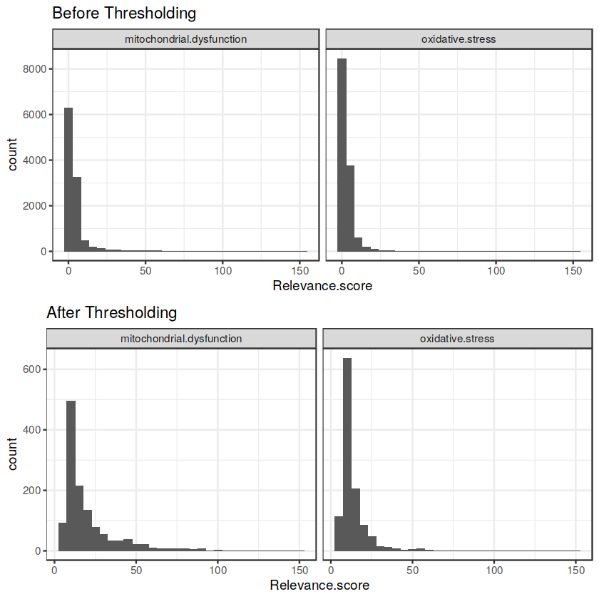

```r
gA<-ggplot(data = ros, aes(x = Relevance.score)) + geom_histogram() + facet_wrap(~Pathway.Name) +
ggtitle('Before Thresholding') + theme_bw()

score.thresh<-7
ros<-ros[ros$Relevance.score > score.thresh,]

gB<-ggplot(data = ros, aes(x = Relevance.score)) + geom_histogram() + facet_wrap(~Pathway.Name) +
ggtitle('After Thresholding') + theme_bw()

g<-cowplot::plot_grid(gA, gB, ncol = 1)
g
```

After thresholding genes for relevance score, the # of genes in each pathway is:

```r
table(ros$Pathway.Name)
```

```
mitochondrial.dysfunction          oxidative.stress
                     1263                      1142
```

Filter for those genes present in the batch-corrected data:

```r
type1.ifns<-intersect(type1.ifns, VariableFeatures(abc.integrated))
inflammasome<-intersect(inflammasome, VariableFeatures(abc.integrated))
mdf<-intersect(ros[ros$Pathway.Name == 'mitochondrial.dysfunction', 'Gene.Symbol'], VariableFeatures(abc.integrated))
os<-intersect(ros[ros$Pathway.Name == 'oxidative.stress', 'Gene.Symbol'], VariableFeatures(abc.integrated))

gene.terms<-list('type1.ifns' = type1.ifns,
                'inflammasome' = inflammasome,
                'mitochondrial.dysfunction' = mdf,
                'oxidative.stress' = os)
```

```r
inflammasome
```

1. 'Casp4'

2. 'Mefv'

3. 'Nlrp3'

4. 'Cd36'

5. 'Eif2ak2'

6. 'Trim30a'

7. 'Gbp5'

```r
type1.ifns
```

1. 'Cd14'

2. 'Flt3'

3. 'Gapdh'

4. 'Hmgb1'

5. 'Hspd1'

6. 'Hsp90aa1'

7. 'Irf8'

8. 'Irf1'

9. 'Mmp12'

10. 'Gbp4'

11. 'Pola1'

12. 'Sirpa'

13. 'Ptprs'

14. 'Rel'

15. 'Relb'

16. 'Syk'

17. 'Irf5'

18. 'Irf7'

19. 'Zbtb20'

20. 'Ifih1'

21. 'Hmgb2'

22. 'Tlr3'

23. 'Tlr7'

24. 'Havcr2'

25. 'Oas3'

26. 'Isg15'

27. 'Samhd1'

28. 'Zbp1'

29. 'Ifitm3'

30. 'Ifitm1'

31. 'Ifitm2'

32. 'Ifitm6'

```r
print(paste0('After filtering for those present in HVGs, there are ', length(mdf),
             ' genes associated with mitochondrial dysfunction'))
print(paste0('After filtering for those present in HVGs, there are ', length(os),
             ' genes associated with oxidative stress'))
```

```
[1] "After filtering for those present in HVGs, there are 107 genes associated with mitochondrial dysfunction"
[1] "After filtering for those present in HVGs, there are 196 genes associated with oxidative stress"
```

```r
# abc.integrated.meta<-get.metacells(abc.integrated, #min_cells = 25, k = 25,
#                                group.by = c("Cell.Type.Level1", 'orig.ident'), ident.group = "Cell.Type.Level1")
```

Let's get the batch-corrected, scaled expression matrix:

```r
gene.terms<-list('type1.ifns' = type1.ifns,
                'inflammasome' = inflammasome,
                'mitochondrial.dysfunction' = mdf,
                'oxidative.stress' = os)
```

```r
expr<-GetAssayData(abc.integrated, assay = 'integrated', slot = 'scale.data')
```

```r
expr<-GetAssayData(abc.integrated, assay = 'integrated', slot = 'scale.data')
expr.genes<-lapply(gene.terms, function(genes) expr[genes, ])
names(expr.genes)<-names(gene.terms)
```

Take the cell-wise median expression across relevant genes:

```r
med.genes<-lapply(expr.genes, function(expr.gene) apply(expr.gene, 2, median))
names(med.genes)<-names(expr.genes)

md<-abc.integrated@meta.data
for (pathway.name in names(med.genes)){
    md[[paste0('Med.', pathway.name)]]<-unlist(unname(med.genes[[pathway.name]]))
}
md<-md[md$Cell.Type.Level1 != 'Unknown', ]
md<-md[c('orig.ident', 'Cell.Type.Level1', paste0('Med.', names(med.genes)))]
```

For each cell type, calculate teh ANOVA p-value across conditions:

```r
anova.genes<-list()
for (pathway.name in names(med.genes)){
    anova.genes[[pathway.name]]<-md %>%
                            select(c('orig.ident', 'Cell.Type.Level1', paste0('Med.', pathway.name))) %>%
                            group_by(Cell.Type.Level1) %>%
                            do(Model = aov(as.formula(paste0('Med.', pathway.name, ' ~ orig.ident')), data=.)) %>%
                            mutate(ANOVA.pval = summary(Model)[[1]][["Pr(>F)"]][1]) %>%
                            select(-one_of(c('Model'))) %>%
                            mutate(ANOVA.fdr = p.adjust(ANOVA.pval, method = 'BH'))
}
```

```
Med.oxidative.stress ~ orig.ident
```

For each cell type, aggregate the pathway expression (median scaled across all genes for a cell) by the median value. Then, take the correlation b/w the aggregated value and the condition:

```r
cors<-md %>%
group_by(Cell.Type.Level1, orig.ident)%>%
summarise(Med.inflammasome=median(Med.inflammasome),
          Med.type1.ifns=median(Med.type1.ifns),
         Med.mitochondrial.dysfunction=median(Med.mitochondrial.dysfunction),
         Med.oxidative.stress=median(Med.oxidative.stress))

mapper<-1:length(levels(cors$orig.ident))
names(mapper)<-levels(cors$orig.ident)
cors['Condition']<-unname(unlist(mapper[as.character(cors$orig.ident)]))

cors.genes<-list()
for (pathway.name in names(med.genes)){
    cors.genes[[pathway.name]]<-cors %>%
            group_by(Cell.Type.Level1)%>%
            select(paste0('Med.', pathway.name), 'Condition') %>%
            rename('Med' = paste0('Med.', pathway.name)) %>%
            mutate(Correlation = cor(Med, Condition, method = 'spearman', use = 'pairwise.complete.obs')) %>%
            select(c('Cell.Type.Level1','Correlation')) %>%
            distinct(.keep_all = TRUE)
}
```

Get the cell type composition (normalized per sample) of Level 1, from Notebook 02

```r
context.freq<-read.csv(paste0(data_path, 'processed/level1.composition.csv'))
context.freq<-context.freq %>%
    select(-one_of(c('Unknown'))) %>%
    rename(orig.ident = names(.)[1])
context.freq<-melt(context.freq, id.vars = c('orig.ident'),
                   variable.name = 'Cell.Type.Level1', value.name = 'Frequency') %>%
            select(2,1, everything())
```

Calculate the correlation b/w the frequency of a cell type and the aggregated median expression of the cell type:

```r
cors<-cors[cors$Cell.Type.Level1 != 'Unknown', ]
ct.mapper<-levels(cors$Cell.Type.Level1)[levels(cors$Cell.Type.Level1) != 'Unknown']
names(ct.mapper)<-levels(context.freq$Cell.Type.Level1)
context.freq[['Cell.Type.Level1']]<-factor(ct.mapper[context.freq$Cell.Type.Level1],
          levels = levels(cors$Cell.Type.Level1)[levels(cors$Cell.Type.Level1) != 'Unknown'])

context.freq[['orig.ident']]<-factor(context.freq$orig.ident,
                                    levels = levels(cors$orig.ident))
cors.freq<-dplyr::inner_join(context.freq, cors, by = c('Cell.Type.Level1', 'orig.ident'))

cors.freq.genes<-list()

for (pathway.name in names(med.genes)){
        cfg<-cors.freq %>%
                    group_by(Cell.Type.Level1)%>%
                    select(paste0('Med.', pathway.name), 'Frequency', 'Cell.Type.Level1') %>%
                    rename('Med' = paste0('Med.', pathway.name)) %>%
                    mutate(Correlation = cor(Med, Frequency, method = 'spearman', use = 'pairwise.complete.obs')) %>%
                    select(c('Cell.Type.Level1','Correlation')) %>%
                    distinct(.keep_all = TRUE)
    cfg[['orig.ident']]<-NA
    cors.freq.genes[[pathway.name]]<-cfg
}
```

Are there any patterns for cell types across contexts with these pathways?

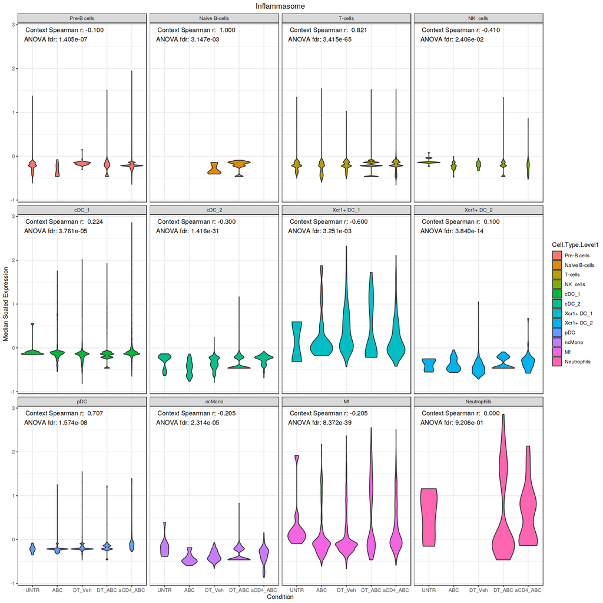

```r
h_ = 15
w_ = 15
options(repr.plot.height=h_, repr.plot.width=w_)

g<-ggplot(data = md, aes(x = orig.ident, y = Med.inflammasome, fill = Cell.Type.Level1)) +
geom_violin() + theme_bw() +
facet_wrap( ~ Cell.Type.Level1) + ggtitle('Inflammasome') +
theme(plot.title = element_text(hjust = 0.5)) +
ylab('Median Scaled Expression') + xlab('Condition') +
geom_text(data=cors.genes[['inflammasome']],
          aes(label=paste("Context Spearman r: ", format(round(Correlation, 3), nsmall = 3), sep=""),
             x = -Inf, y = Inf, hjust = -0.1, vjust = 2))+
geom_text(data=anova.genes[['inflammasome']],
          aes(label=paste("ANOVA fdr: ", formatC(ANOVA.fdr, format = "e", digits = 3), sep=""),
             x = -Inf, y = Inf, hjust = -0.1, vjust = 4))

g
```

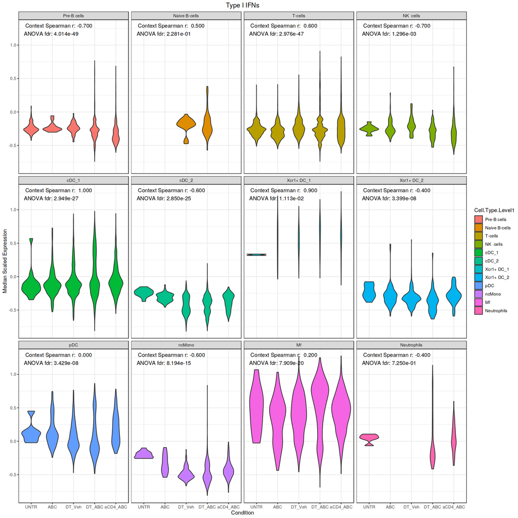

```r
h_ = 15
w_ = 15
options(repr.plot.height=h_, repr.plot.width=w_)

g<-ggplot(data = md, aes(x = orig.ident, y = Med.type1.ifns, fill = Cell.Type.Level1)) +
geom_violin() + theme_bw() +
facet_wrap( ~ Cell.Type.Level1) + ggtitle('Type I IFNs') +
theme(plot.title = element_text(hjust = 0.5)) +
ylab('Median Scaled Expression') + xlab('Condition') +
geom_text(data=cors.genes[['type1.ifns']],
          aes(label=paste("Context Spearman r: ", format(round(Correlation, 3), nsmall = 3), sep=""),
             x = -Inf, y = Inf, hjust = -0.1, vjust = 2))+
geom_text(data=anova.genes[['type1.ifns']],
          aes(label=paste("ANOVA fdr: ", formatC(ANOVA.fdr, format = "e", digits = 3), sep=""),
             x = -Inf, y = Inf, hjust = -0.1, vjust = 4))

g
```

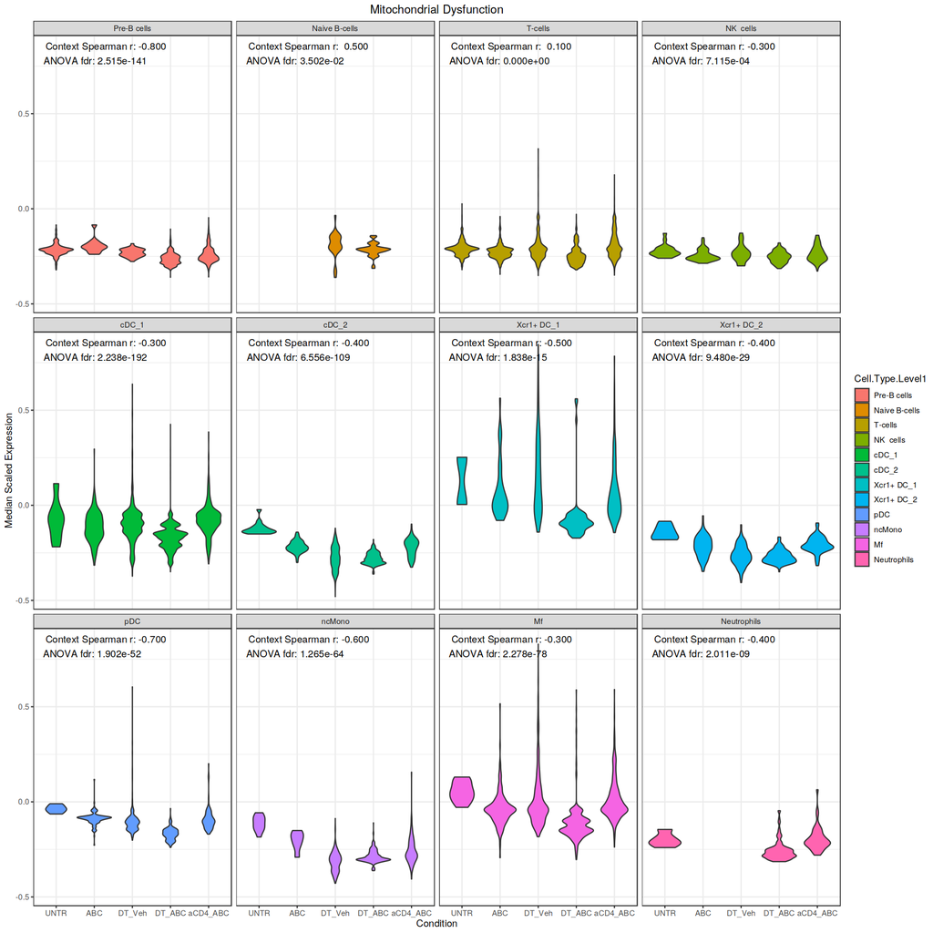

```r
h_ = 15
w_ = 15
options(repr.plot.height=h_, repr.plot.width=w_)

g<-ggplot(data = md, aes(x = orig.ident, y = Med.mitochondrial.dysfunction, fill = Cell.Type.Level1)) +
geom_violin() + theme_bw() +
facet_wrap( ~ Cell.Type.Level1) + ggtitle('Mitochondrial Dysfunction') +
theme(plot.title = element_text(hjust = 0.5)) +
ylab('Median Scaled Expression') + xlab('Condition') +
geom_text(data=cors.genes[['mitochondrial.dysfunction']],
          aes(label=paste("Context Spearman r: ", format(round(Correlation, 3), nsmall = 3), sep=""),
             x = -Inf, y = Inf, hjust = -0.1, vjust = 2))+
geom_text(data=anova.genes[['mitochondrial.dysfunction']],
          aes(label=paste("ANOVA fdr: ", formatC(ANOVA.fdr, format = "e", digits = 3), sep=""),
             x = -Inf, y = Inf, hjust = -0.1, vjust = 4))

g
```

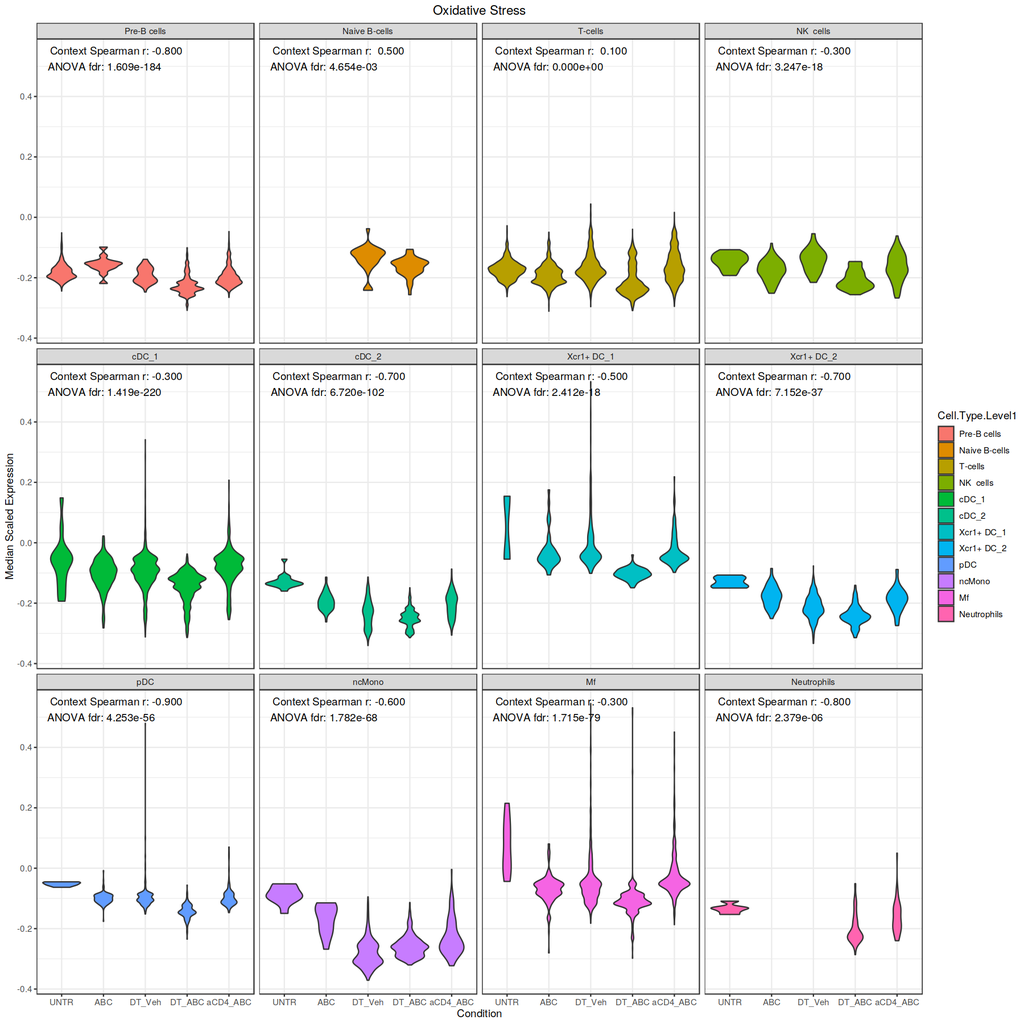

```r
h_ = 15
w_ = 15
options(repr.plot.height=h_, repr.plot.width=w_)

g<-ggplot(data = md, aes(x = orig.ident, y = Med.oxidative.stress, fill = Cell.Type.Level1)) +
geom_violin() + theme_bw() +
facet_wrap( ~ Cell.Type.Level1) + ggtitle('Oxidative Stress') +
theme(plot.title = element_text(hjust = 0.5)) +
ylab('Median Scaled Expression') + xlab('Condition') +
geom_text(data=cors.genes[['oxidative.stress']],
          aes(label=paste("Context Spearman r: ", format(round(Correlation, 3), nsmall = 3), sep=""),
             x = -Inf, y = Inf, hjust = -0.1, vjust = 2))+
geom_text(data=anova.genes[['oxidative.stress']],
          aes(label=paste("ANOVA fdr: ", formatC(ANOVA.fdr, format = "e", digits = 3), sep=""),
             x = -Inf, y = Inf, hjust = -0.1, vjust = 4))

g
```

Scatter plots look at cell type frequency in a condition (x-axis) vs median expression of a pathway (again aggregated by median in that cell type). This does not consider any order of conditions, so spearman correlation is taken instead. However, scatter plot dots are colored by the condition.

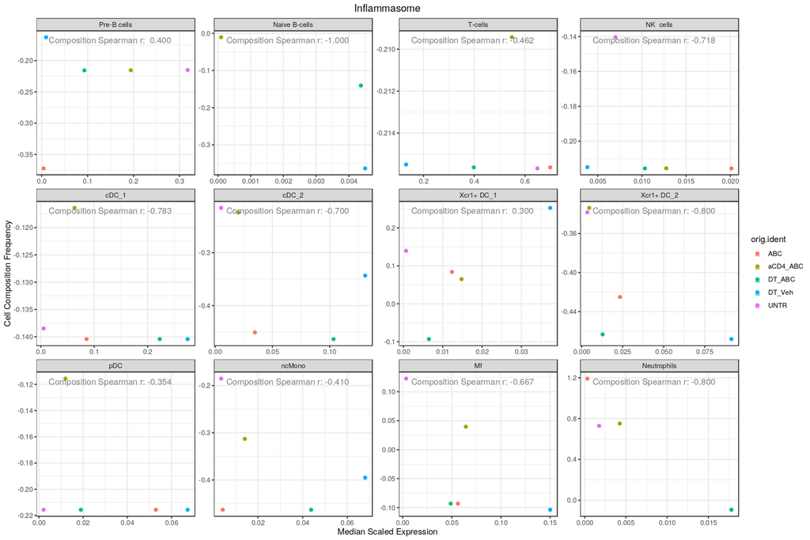

```r
h_ = 10
w_ = 15
options(repr.plot.height=h_, repr.plot.width=w_)

g<-ggplot(data = cors.freq, aes(x = Frequency, y = Med.inflammasome, color = orig.ident)) +
geom_point() + theme_bw() +
facet_wrap( ~ Cell.Type.Level1, scales = 'free') + ggtitle('Inflammasome') +
theme(plot.title = element_text(hjust = 0.5)) +
ylab('Cell Composition Frequency') + xlab('Median Scaled Expression') +
geom_text(data=cors.freq.genes[['inflammasome']],
         aes(label = paste("Composition Spearman r: ", format(round(Correlation, 3), nsmall = 3), sep=""),
         x = -Inf, y = Inf, hjust = -0.1, vjust = 2))

g
```

```r
names(cors.freq)
```

1. 'Cell.Type.Level1'

2. 'orig.ident'

3. 'Frequency'

4. 'Med.inflammasome'

5. 'Med.type1.ifns'

6. 'Med.mitochondrial.dysfunction'

7. 'Med.oxidative.stress'

8. 'Condition'

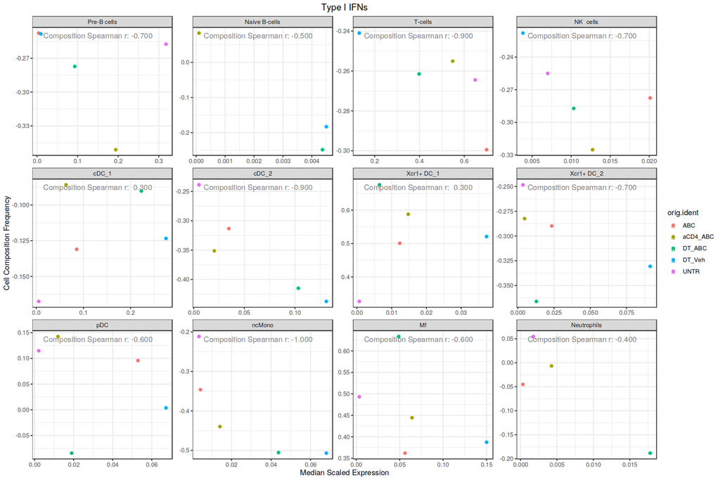

```r
h_ = 10
w_ = 15
options(repr.plot.height=h_, repr.plot.width=w_)

g<-ggplot(data = cors.freq, aes(x = Frequency, y = Med.type1.ifns, color = orig.ident)) +
geom_point() + theme_bw() +
facet_wrap( ~ Cell.Type.Level1, scales = 'free') + ggtitle('Type I IFNs') +
theme(plot.title = element_text(hjust = 0.5)) +
ylab('Cell Composition Frequency') + xlab('Median Scaled Expression') +
geom_text(data=cors.freq.genes[['type1.ifns']],
         aes(label = paste("Composition Spearman r: ", format(round(Correlation, 3), nsmall = 3), sep=""),
         x = -Inf, y = Inf, hjust = -0.1, vjust = 2))

g
```

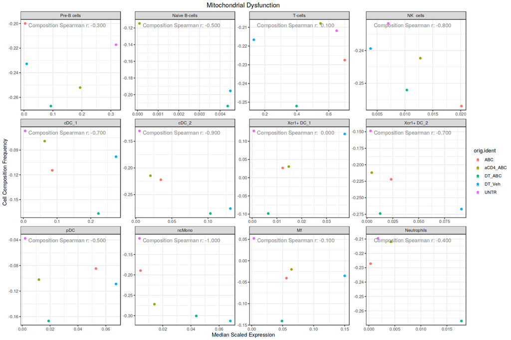

```r
h_ = 10
w_ = 15
options(repr.plot.height=h_, repr.plot.width=w_)

g<-ggplot(data = cors.freq, aes(x = Frequency, y = Med.mitochondrial.dysfunction, color = orig.ident)) +
geom_point() + theme_bw() +
facet_wrap( ~ Cell.Type.Level1, scales = 'free') + ggtitle('Mitochondrial Dysfunction') +
theme(plot.title = element_text(hjust = 0.5)) +
ylab('Cell Composition Frequency') + xlab('Median Scaled Expression') +
geom_text(data=cors.freq.genes[['mitochondrial.dysfunction']],
         aes(label = paste("Composition Spearman r: ", format(round(Correlation, 3), nsmall = 3), sep=""),
         x = -Inf, y = Inf, hjust = -0.1, vjust = 2))

g
```

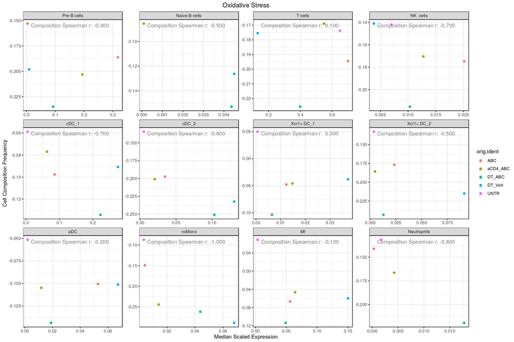

```r
h_ = 10
w_ = 15
options(repr.plot.height=h_, repr.plot.width=w_)

g<-ggplot(data = cors.freq, aes(x = Frequency, y = Med.oxidative.stress, color = orig.ident)) +
geom_point() + theme_bw() +
facet_wrap( ~ Cell.Type.Level1, scales = 'free') + ggtitle('Oxidative Stress') +
theme(plot.title = element_text(hjust = 0.5)) +
ylab('Cell Composition Frequency') + xlab('Median Scaled Expression') +
geom_text(data=cors.freq.genes[['oxidative.stress']],
         aes(label = paste("Composition Spearman r: ", format(round(Correlation, 3), nsmall = 3), sep=""),
         x = -Inf, y = Inf, hjust = -0.1, vjust = 2))

g
```